# Data Analysis Basics with SPSS

SoTL Writing Retreat, 2023

Clay Ford, UVA Library

## Topics

- Download and install SPSS
- Importing data into SPSS
- Preparing data for analysis
- Descriptive statistics
- Basic visualization
- Example of a full statistical analysis

## Download/Install SPSS

- SPSS is free for UVA students, faculty, and staff. Download from the [UVA Software Gateway](https://virginia.service-now.com/its/?id=sg_catalog&sys_id=709c5ed4dbe5e34c2192e6650596198a).
- Select the “Teaching & Research” version for your operating system (Windows or Mac). File is about 860 MB.
- Installation instructions are on this page: https://data.library.virginia.edu/research-software/spss/
- You need to “authorize” SPSS using the UVA Authorization Code, which is provided when you download SPSS. It’s 20 characters in length.

## Download

Go to the [UVA Software Gateway](https://virginia.service-now.com/its/?id=sg_catalog&sys_id=709c5ed4dbe5e34c2192e6650596198a). Click the one for your operating system.

[figure not shown]

## Activation code

Be sure to copy and save the “Activation Code”.

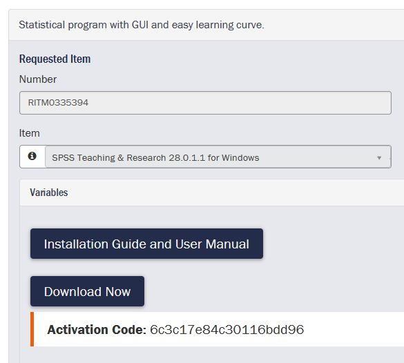

## After installation…

You should see this dialog. Click “Launch License Wizard” to authorize the software with the “Activation Code”.

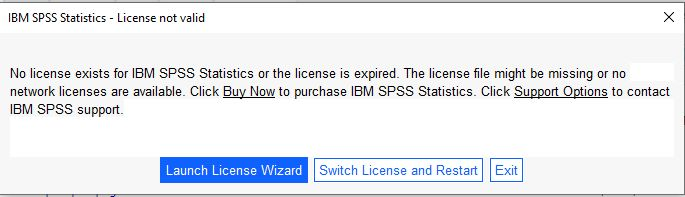

## Select Authorized user license

Select the first option (it should be the default) and click Next.

[figure not shown]

## Enter code

Enter the “Activation Code” in the “Enter Code” field, click Add, and click Next.

[figure not shown]

## Successful authorization

If all went well, you should see something like this. Now you’re ready to use SPSS!

Heads up: you’ll need reauthorize SPSS every year.

[figure not shown]

## Importing Data

- SPSS is for data analysis, not data entry.
- You almost always need to *import* data into SPSS.
- Data typically come from surveys, public use data files, databases, or Excel.
- To import an Excel file: **File**…**Import Data**…**Excel**…
- To import a CSV file: **File**…**Import Data**…**CSV Data**…

## Import Excel example

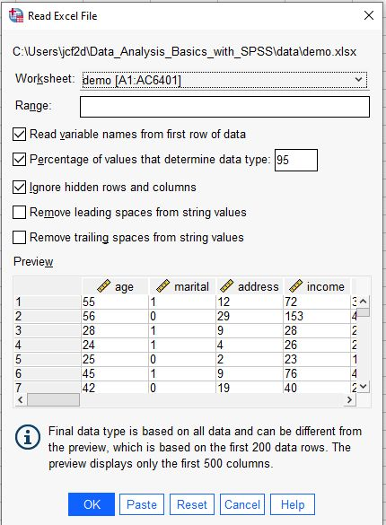

## Good Excel vs Bad Excel

When it comes to entering data into Excel, keep it simple.

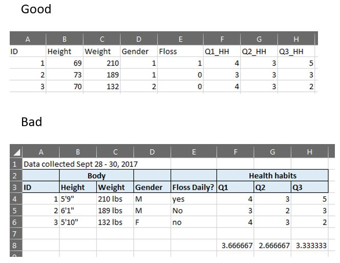

## Save as SPSS Data

- After you import data you’ll want to save as a SPSS data file (.sav).
- **File**…**Save As**…
- Now you can just open the SAV file when you want to work with the data
- Note: some public use data sets are already SAV files.

## Preparing Data

Three things we usually want to check and/or fix:

1. variable labels
2. value labels
3. measure type

## Variable labels

- A variable *name* usually is brief and has no spaces or special characters. For example: “inccat”
- A variable *label* provides more detail. For example: “Income Category”
- You’ll probably want to add variable labels if none exist
- Variable labels appear in plots and output

## Adding variable labels

On **Variable View** tab, enter a label in the Label column

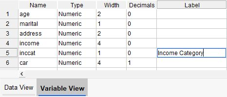

## Value labels

- A variable has *values*. Values sometimes need descriptive labels.
- For example, a variable named “marital” may consist of 0 and 1, where 0 = Unmarried and 1 = Married
- Adding value labels allows us to toggle between 0/1 and unmarried/married.
- Value labels appear in plots and outputs

## Adding value labels

On **Variable View** tab, go to the Values column and click in the cell for the variable that you want to add value labels and click the three dots button

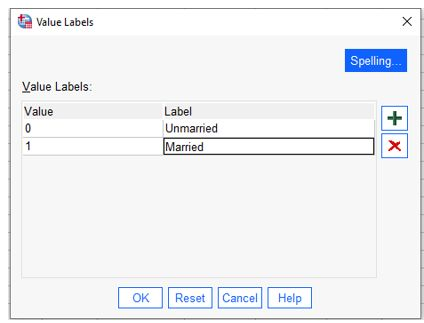

## Measure type

There are three types of measures in SPSS:

1. **Scale** (numeric values)
2. **Ordinal** (ordered categories; eg: 1 = never, 2 = rarely, 3 = sometimes,…)
3. **Nominal** (unordered categories; eg: O positive, O negative, A positive,…)

Often these are fine as is, but sometimes you need to modify; for example, if numbers represent categories, then change from Scale to Ordinal or Nominal

## Changing Measure type

On **Variable View** tab, go to the Measure column and set as needed

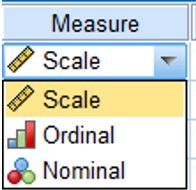

## Descriptive statistics

For numeric variables we may be interested in

- Smallest and largest values (minimum and maximum)
- Measure of center (mean or median)
- How spread out is it (standard deviation or interquartile range)
- Relationship between numeric variables (correlation)

For categorical variables we may be interested in

- Number in each category
- Proportion in each category
- Cross tabulations; eg, gender (M/F) vs floss (Y/N)

## Numeric summary stats

Here’s one approach to getting summary stats for numeric data

1. Go to Analyze…Descriptive Statistics…Frequencies
2. Select numeric variables and click “add” arrow
3. Click Statistics… button
4. Select Quartiles, Median, Mean, Std. deviation, Minimum and Maximum
5. Uncheck “Display frequency tables”
6. Click OK

## Categorical summary stats

1. Go to Analyze…Descriptive Statistics…Frequencies
2. Click Reset if you previously ran numeric summary stats
3. Make sure “Display frequency tables” is checked

## Summary stats by group

It’s often instructive to examine summary stats by groups. For example: mean income by gender

1. Go to Analyze…Compare Means…Means…
2. Add a numeric variable to the Dependent List and a categorical variable to the Independent List
3. Click Options… to add other estimates such as the median, min, max, etc.
4. Click OK

## Cross tabulations

We often want to tally categorical variables conditional on another categorical variable. For example: how many men and women are in each income category?

1. Go to Analyze…Descriptive Statistics…Crosstabs…
2. Add a categorical variable to Rows, and another to Columns
3. Click the Cells… button in the Crosstabs dialog to add row and column percentages
4. Click OK

## Basic Visualization

Chart Builder in SPSS allows us to quickly visualize our data

1. Go to Graphs…Chart Builder…
2. Browse the Gallery for the type of graph you want to create
3. Drag the graph thumbnail into the empty window to get started

## Chart Builder

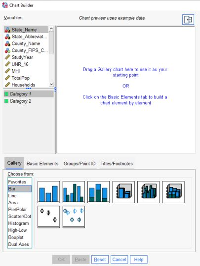

## Output

All output is sent to the Viewer. This file can be saved. It will have an .spv file extension.

Graphs and tables can be copied out of the Viewer file and pasted into reports and presentations.

The Viewer file can be shared with colleagues.

The View file can be exported as a PDF file (among other formats) and shared with colleagues who don’t have SPSS.

## Statistical inference

- We usually don’t have all the data but just a *sample*.
- We hope the sample is representative of the *population*.
- We use sample statistics to *infer* properties of the population.
- Example: mean weight of student backpacks at UVA.
- Not practical to weigh all 23,000 backpacks, so take a *random sample* and use the mean of the sample to estimate the population mean.
- Statistical inference attempts to quantify the *uncertainty* in estimates using standard errors and probability.

## Statistical inference

- Statistical inference involves topics such as hypothesis testing, confidence intervals, multiple regression, ANOVA, structural equation modeling, multilevel modeling, etc.
- This is why researchers need software like SPSS (or R, Stata, SAS, Minitab, GraphPad Prism, …)
- You’ll probably only ever use a fraction of the statistical routines available.

## Analysis example

How has cost of preschool child care increased in Virginia from 2008 - 2018?

National Database of Childcare Prices: https://www.dol.gov/agencies/wb/topics/featured-childcare

The National Database of Childcare Prices (NDCP) offers childcare price data by childcare provider type, age of children, and county characteristics. Data are available from 2008 to 2018.

## Steps for analysis

1. Import data
2. Inspect data
3. Summarize and visualize
4. Model preschool cost as a function of year with county as a random effect (Example of multilevel model)
5. Save Viewer file

See `SPSS_Analysis_Example.pdf` for detailed steps.

## Learn More

- Google is always your friend
- In SPSS, go to Help…Topics, scroll to Tutorial and begin the official SPSS Tutorial
- In SPSS, go to Help…Topics, scroll to Case Studies and pick a topic of interest
- In SPSS, go to Help…Topics, scroll to Statistics Coach and find help on a topic of interest

## UVA StatLab

Thank you for coming!

For help with study design and statistical analysis, email to set up an appointment: statlab@virginia.edu

For more information:  
https://data.library.virginia.edu/statlab/

We also teach free workshops:  
http://data.library.virginia.edu/training/

[figure not shown]

clayford@virginia.edu | GitHub [@clayford](https://github.com/clayford)